[Imtiaj.](https://imtiajiqbalmahfuj.github.io/index.html#top)

# Flash Flood Hazard Assessment & NbS Framework: Feni & Noakhali

### GIS-Integrated Fuzzy AHP-MCDA for Climate-Resilient Disaster Management

> *Predicting vulnerability and proposing Nature-based Solutions to safeguard 1.2 million lives in the wake of the 2024 flash floods. 🌊*

[figure not shown]

> **Author:** Imtiaj Iqbal Mahfuj

## 📝 Overview

This project explores **spatial patterns**, integrates **remote sensing datasets**, and applies **geospatial analysis** to visualize and analyze flash flood susceptibility in the Feni and Noakhali districts of Bangladesh. Following the catastrophic August 2024 flood event that affected 5.8 million people, this study aims to uncover key insights that support data-driven decision-making for urban planners and disaster management authorities.

The **problem statement** centers on the increasing frequency of transboundary and monsoon-driven flash floods which traditional "grey" infrastructure struggles to mitigate. By integrating a **Fuzzy Analytical Hierarchy Process (FAHP)** with **Multi-Criteria Decision Analysis (MCDA)**, the research overcomes the subjectivity of expert opinions to produce a highly accurate Flood Hazard Index (FHI).

The primary **beneficiaries** include regional policy-makers, environmental researchers, and local communities who can utilize these maps for better land-use planning and climate adaptation. The **summary** of the findings highlights Hatiya Island as a "Very High" hazard zone and proposes ecosystem-based strategies like mangrove restoration and floating agriculture to build long-term resilience.

## 🛠️ Tools & Technologies

## ⚙️ Methodology

[output not shown]

Graphical Methodology

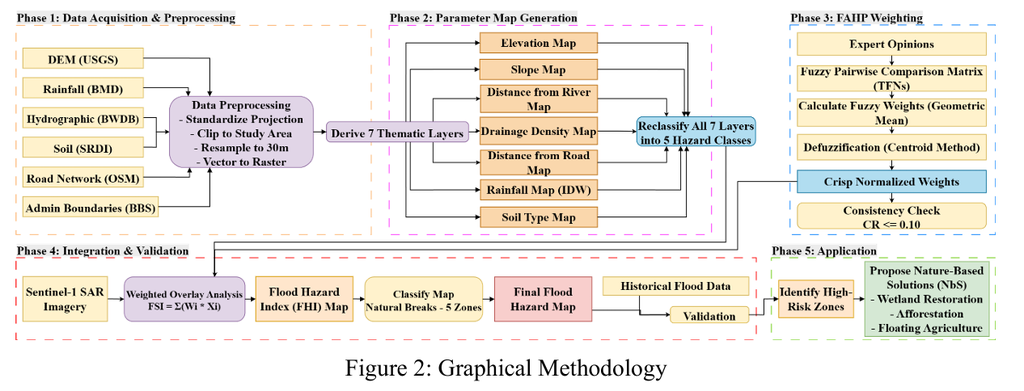

Study Area (Noakhali & Feni)

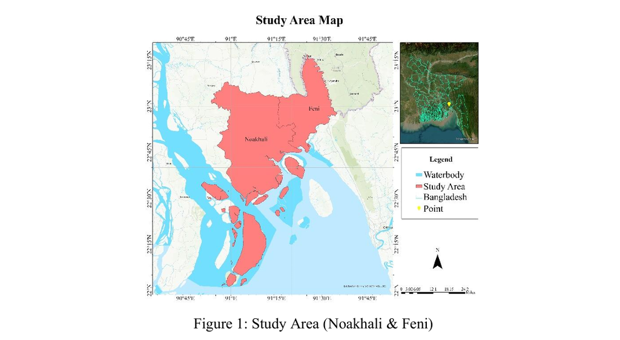

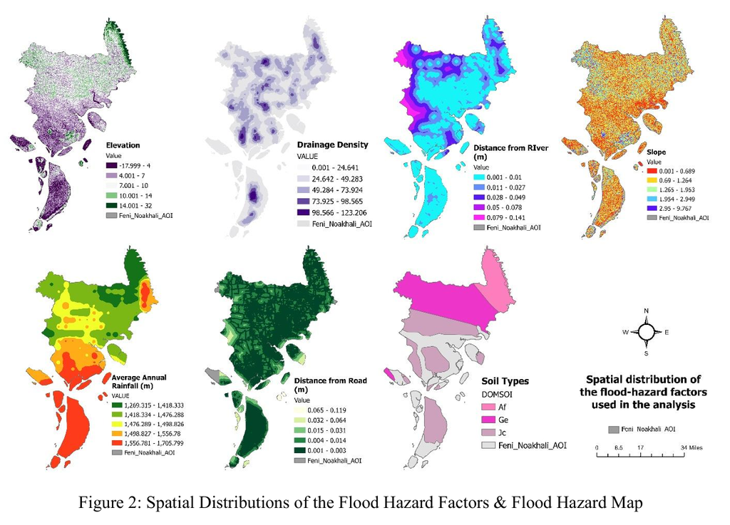

Pairwise comparison matrix for flood hazard contributing factors

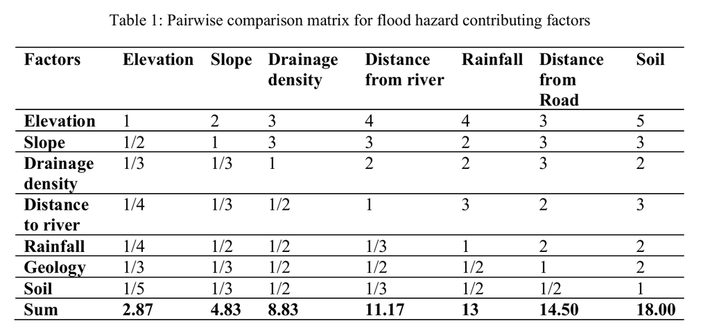

## 📊 Results & Insights

[figure not shown]

*Caption: Spatial distribution of flood hazard zones.*

## ❓ Why this project?

- **The Implementation Gap:** Existing literature often focuses on mapping without providing site-specific, actionable adaptation strategies. This project bridges that gap by proposing NbS.
- **Uncertainty Management:** Standard AHP struggles with human subjectivity; the use of **Fuzzy Logic** ensures more robust and reliable parameter weighting for natural phenomena.
- **Climate Action:** Directly aligns with **SDG 13**, offering a proactive ecosystem-based resilience framework rather than reactive engineering solutions.

## ✨ Features

- **FAHP-GIS Model:** A replicable and scalable model for multi-criteria disaster assessment.
- **NbS Toolbox:** Recommendations for wetland restoration, afforestation, and floating agriculture.
- **Validation-Backed:** Model results are validated against real-world historical flood data (August 2024).
- **Exportable Assets:** High-resolution GeoTIFF hazard maps and thematic vector layers.

## 📎 Links

- 🔗 [See more in LinkedIn](https://linkedin.com/in/imtiajiqbalmahfuj)
- 📄 [Conference Paper (ICCESD 2026)](https://imtiajiqbalmahfuj.github.io/)

## 🔖 Tags

`GIS` `Remote Sensing` `Geospatial Python` `Fuzzy AHP` `Flood Management` `Climate Resilience` `Bangladesh` `NbS`

## 📌 Credits & Shoutouts

- 👨‍💻 **Author:** [Imtiaj Iqbal Mahfuj](https://imtiajiqbalmahfuj.github.io/)
- 🙌 **Inspiration:** Special thanks to the ICCESD 2026 organizing committee and the Rajshahi University of Engineering & Technology (RUET).
- 🗂️ **Data Sources:** USGS, BMD, BWDB, SRDI, OSM, and BBS.

## 🧾 Citation

If you use or refer to this work, please cite as:

> *Mahfuj, Imtiaj Iqbal & Tamim, Nawreen Ferdous & Rashid, Towfiqur & Adib, Junaid. (2026). FLASH FLOOD HAZARD ASSESSMENT USING A GIS-INTEGRATED FUZZY AHP-MCDA TO INFORM NATURE-BASED SOLUTIONS IN FENI AND NOAKHALI, BANGLADESH.* [https://www.researchgate.net/publication/400576696_FLASH_FLOOD_HAZARD_ASSESSMENT_USING_A_GIS-INTEGRATED_FUZZY_AHP-MCDA_TO_INFORM_NATURE-BASED_SOLUTIONS_IN_FENI_AND_NOAKHALI_BANGLADESH]

## 💬 Connect with Me

📧 Email: imtiajiqbal.ruet@gmail.com 🌐 Portfolio: https://imtiajiqbalmahfuj.github.io/